# STA 141A project

Bohan Sun

2025-03-17

## 1.Introduction

Understanding how neural activity patterns relate to behavioral outcomes is crucial in neuroscience. This study analyzes data from a visual discrimination task where mice were presented with varying contrast stimuli on both sides and their success in responding was recorded along with neural activity. The dataset comprises 18 sessions from 4 mice, with detailed recordings of neural spikes from multiple brain areas. Our analysis aims to: 1. Characterize neural activity patterns across different brain regions 2. Identify relationships between stimulus conditions and behavioral outcomes 3. Develop a predictive model for trial success based on neural and stimulus features

## 2.Background

-ref: Course_project_description.html In this project, I analyze a subset of data collected by Steinmetz et al. (2019). While this document provides the basic understanding of the experiments, In the study conducted by Steinmetz et al. (2019), experiments were performed on a total of 10 mice over 39 sessions. Each session comprised several hundred trials, during which visual stimuli were randomly presented to the mouse on two screens positioned on both sides of it. The stimuli varied in terms of contrast levels, which took values in {0, 0.25, 0.5, 1}, with 0 indicating the absence of a stimulus. The mice were required to make decisions based on the visual stimuli, using a wheel controlled by their forepaws. A reward or penalty (i.e., feedback) was subsequently administered based on the outcome of their decisions. In particular,

When left contrast > right contrast, success (1) if turning the wheel to the right and failure (-1) otherwise. When right contrast > left contrast, success (1) if turning the wheel to the left and failure (-1) otherwise. When both left and right contrasts are zero, success (1) if holding the wheel still and failure (-1) otherwise. When left and right contrasts are equal but non-zero, left or right will be randomly chosen (50%) as the correct choice.

## 3.Exploratory Data Analysis

### 3.1 Data Structure Analysis

```r
session=list()
session_summary <- data.frame()

for(i in 1:18){
  session[[i]]=readRDS(paste('C:/Users/hong7/Desktop/sessions/session',i,'.rds',sep=''))

summary_row <- data.frame(
    session_id = i,
    mouse_name = session[[i]]$mouse_name,
    date_exp = session[[i]]$date_exp,
    n_trials = length(session[[i]]$feedback_type),
    n_neurons = length(session[[i]]$brain_area),
    n_brain_areas = length(unique(session[[i]]$brain_area))
  )
  session_summary <- rbind(session_summary, summary_row)
}

print("Session Basic Information:")
```

```
## [1] "Session Basic Information:"
```

```r
print(session_summary)
```

```
##    session_id mouse_name   date_exp n_trials n_neurons n_brain_areas
## 1           1       Cori 2016-12-14      114       734             8
## 2           2       Cori 2016-12-17      251      1070             5
## 3           3       Cori 2016-12-18      228       619            11
## 4           4  Forssmann 2017-11-01      249      1769            11
## 5           5  Forssmann 2017-11-02      254      1077            10
## 6           6  Forssmann 2017-11-04      290      1169             5
## 7           7  Forssmann 2017-11-05      252       584             8
## 8           8      Hench 2017-06-15      250      1157            15
## 9           9      Hench 2017-06-16      372       788            12
## 10         10      Hench 2017-06-17      447      1172            13
## 11         11      Hench 2017-06-18      342       857             6
## 12         12  Lederberg 2017-12-05      340       698            12
## 13         13  Lederberg 2017-12-06      300       983            15
## 14         14  Lederberg 2017-12-07      268       756            10
## 15         15  Lederberg 2017-12-08      404       743             8
## 16         16  Lederberg 2017-12-09      280       474             6
## 17         17  Lederberg 2017-12-10      224       565             6
## 18         18  Lederberg 2017-12-11      216      1090            10
```

```r
# Output summary statistics

print(paste("Total number of experimental mice:", length(unique(session_summary$mouse_name))))
```

```
## [1] "Total number of experimental mice: 4"
```

```r
print(paste("Total number of experimental sessions:", nrow(session_summary)))
```

```
## [1] "Total number of experimental sessions: 18"
```

```r
print(paste("Average number of trials per session:", round(mean(session_summary$n_trials), 2)))
```

```
## [1] "Average number of trials per session: 282.28"
```

```r
print(paste("Average number of neurons per session:", round(mean(session_summary$n_neurons), 2)))
```

```
## [1] "Average number of neurons per session: 905.83"
```

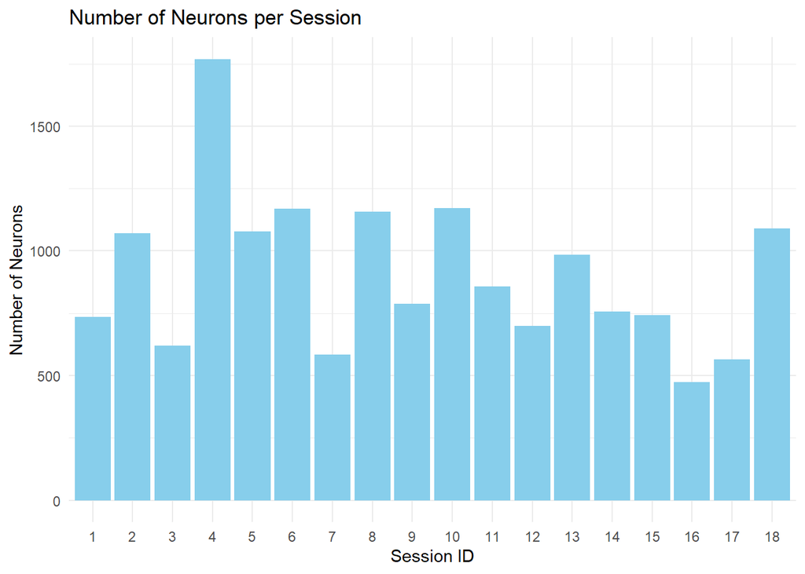

```r
ggplot(session_summary, aes(x=factor(session_id), y=n_neurons)) +
  geom_bar(stat="identity", fill="skyblue") +
  labs(title="Number of Neurons per Session",
       x="Session ID",
       y="Number of Neurons") +
  theme_minimal()
```

Finding - The number of recorded neurons fluctuates in each session, particularly in **Session 4** and **Session 16**, which may require further analysis to determine if there are any anomalies. - The absence of a clear trend may suggest that the number of neurons fluctuates randomly. - Further analysis is needed to explore the relationship between stimulus conditions and the number of neurons.

### 3.2 Stimulus Conditions and Feedback Type Analysis

```r
session_1 <- data.frame(
  trial = 1:length(session[[1]]$feedback_type),
  feedback = session[[1]]$feedback_type,
  contrast_left = session[[1]]$contrast_left,
  contrast_right = session[[1]]$contrast_right
)

print(paste("Total number of trials:", nrow(session_1)))
```

```
## [1] "Total number of trials: 114"
```

```r
print(paste("Number of successful trials:", sum(session_1$feedback == 1)))
```

```
## [1] "Number of successful trials: 69"
```

```r
print(paste("Number of failed trials:", sum(session_1$feedback == -1)))
```

```
## [1] "Number of failed trials: 45"
```

```r
print(paste("Success rate:", round(mean(session_1$feedback == 1) * 100, 2), "%"))
```

```
## [1] "Success rate: 60.53 %"
```

```r
# Unique values for left contrast
print(unique(session_1$contrast_left))
```

```
## [1] 0.00 0.50 1.00 0.25
```

```r
# Unique values for right contrast
print(unique(session_1$contrast_right))
```

```
## [1] 0.50 0.00 1.00 0.25
```

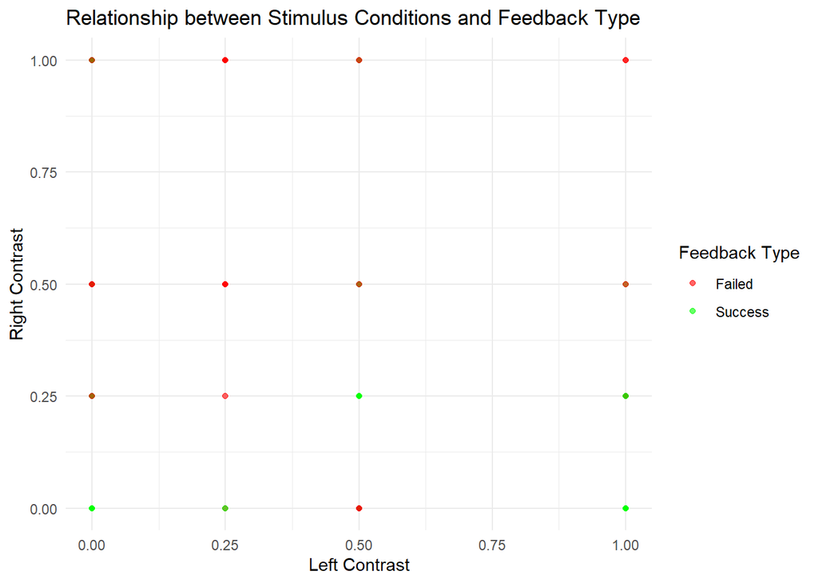

```r
ggplot(session_1, aes(x=contrast_left, y=contrast_right, color=factor(feedback))) +
  geom_point(alpha=0.6) +
  scale_color_manual(values=c("red", "green"), labels=c("Failed", "Success")) +
  labs(title="Relationship between Stimulus Conditions and Feedback Type",
       x="Left Contrast",
       y="Right Contrast",
       color="Feedback Type") +
  theme_minimal()
```

Finding: - The failed data points are mainly concentrated in the upper left area (right contrast = 1), while the successful data points are primarily in the lower right area (left contrast = 1). This suggests that certain contrast combinations may be more likely to result in successful feedback.

### 3.3 Neural Activity Analysis

```r
trial_spks <- session[[5]]$spks[[11]]
brain_areas <- session[[5]]$brain_area

# Analyzed Session ID: 5
# Analyzed Trial ID: 11
print(paste("Total Number of Neurons:", nrow(trial_spks)))
```

```
## [1] "Total Number of Neurons: 1077"
```

```r
print(paste("Number of Time Windows:", ncol(trial_spks)))
```

```
## [1] "Number of Time Windows: 40"
```

```r
# Calculate average firing rate for each brain area
spks_by_area <- data.frame(
  brain_area = brain_areas,
  firing_rate = rowMeans(trial_spks)
)

area_means <- aggregate(firing_rate ~ brain_area,
                       data = spks_by_area,
                       FUN = mean)

print(area_means)
```

```
##    brain_area firing_rate
## 1         ACA 0.009433962
## 2         CA1 0.007142857
## 3          DG 0.029687500
## 4         MOs 0.013793103
## 5         OLF 0.011464088
## 6         ORB 0.007031250
## 7          PL 0.007142857
## 8        root 0.045133588
## 9         SUB 0.023514851
## 10       VISa 0.015404040
```

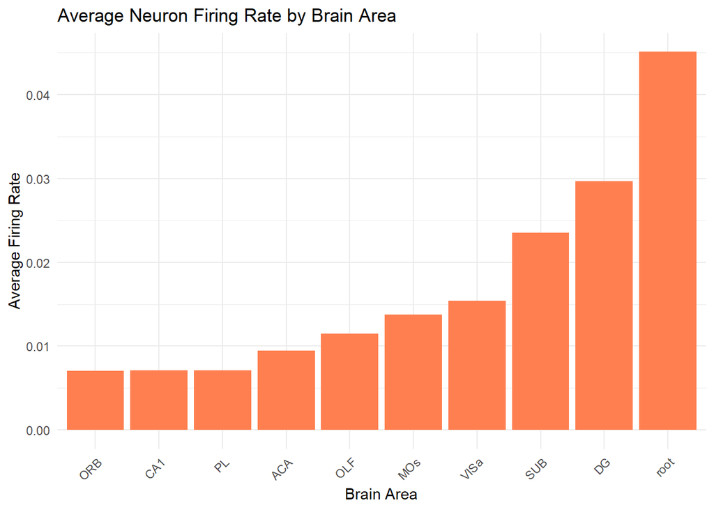

```r
# Plot average firing rates across brain areas
ggplot(area_means, aes(x=reorder(brain_area, firing_rate), y=firing_rate)) +
  geom_bar(stat="identity", fill="coral") +
  labs(title="Average Neuron Firing Rate by Brain Area",
       x="Brain Area",
       y="Average Firing Rate") +
  theme_minimal() +
  theme(axis.text.x = element_text(angle = 45, hjust = 1))
```

```r
# Time series analysis
time_series <- colMeans(trial_spks)
time_df <- data.frame(
  time_bin = 1:length(time_series),
  avg_firing_rate = time_series
)

print(paste("Maximum firing rate:", round(max(time_series), 4)))
```

```
## [1] "Maximum firing rate: 0.0511"
```

```r
print(paste("Minimum firing rate:", round(min(time_series), 4)))
```

```
## [1] "Minimum firing rate: 0.0176"
```

```r
print(paste("Average firing rate:", round(mean(time_series), 4)))
```

```
## [1] "Average firing rate: 0.0293"
```

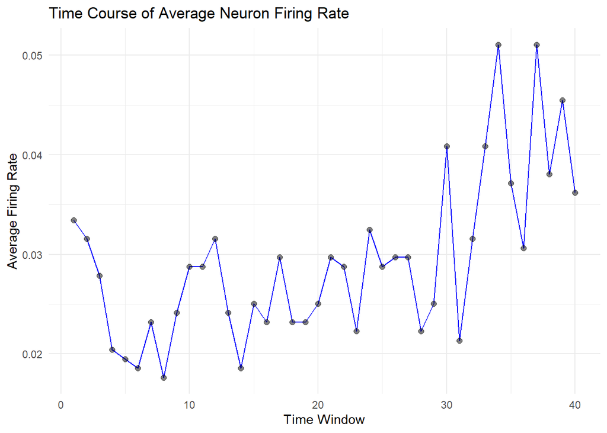

```r
# Plot time series
ggplot(time_df, aes(x=time_bin, y=avg_firing_rate)) +
  geom_line(color="blue") +
  geom_point(size=2, alpha=0.5) +
  labs(title="Time Course of Average Neuron Firing Rate",
       x="Time Window",
       y="Average Firing Rate") +
  theme_minimal()
```

Finding - The overall firing rate shows a fluctuating upward trend over the time window. - The highest firing rate occurs in the **30-40** time window, which may indicate that the stimulus is strongest in this period. - A high firing rate at **0** may indicate the presence of stress response.

### 3.4 Cross-Session Analysis

```r
# Calculate average success rate for each session
success_rates <- data.frame(
  session_id = 1:18,
  mouse_name = sapply(session, function(x) x$mouse_name),
  success_rate = sapply(session, function(x) mean(x$feedback_type == 1))
)

print(success_rates)
```

```
##    session_id mouse_name success_rate
## 1           1       Cori    0.6052632
## 2           2       Cori    0.6334661
## 3           3       Cori    0.6622807
## 4           4  Forssmann    0.6666667
## 5           5  Forssmann    0.6614173
## 6           6  Forssmann    0.7413793
## 7           7  Forssmann    0.6706349
## 8           8      Hench    0.6440000
## 9           9      Hench    0.6854839
## 10         10      Hench    0.6196868
## 11         11      Hench    0.7953216
## 12         12  Lederberg    0.7382353
## 13         13  Lederberg    0.7966667
## 14         14  Lederberg    0.6940299
## 15         15  Lederberg    0.7648515
## 16         16  Lederberg    0.7178571
## 17         17  Lederberg    0.8303571
## 18         18  Lederberg    0.8055556
```

```r
# Calculate average success rate for each mouse
mouse_avg_success <- aggregate(success_rate ~ mouse_name,
                             data = success_rates,
                             FUN = function(x) round(mean(x) * 100, 2))
# Average success rate by mouse
print(mouse_avg_success)
```

```
##   mouse_name success_rate
## 1       Cori        63.37
## 2  Forssmann        68.50
## 3      Hench        68.61
## 4  Lederberg        76.39
```

```r
print(paste("Highest session success rate:", round(max(success_rates$success_rate) * 100, 2), "%"))
```

```
## [1] "Highest session success rate: 83.04 %"
```

```r
print(paste("Lowest session success rate:", round(min(success_rates$success_rate) * 100, 2), "%"))
```

```
## [1] "Lowest session success rate: 60.53 %"
```

```r
print(paste("Average session success rate:", round(mean(success_rates$success_rate) * 100, 2), "%"))
```

```
## [1] "Average session success rate: 70.74 %"
```

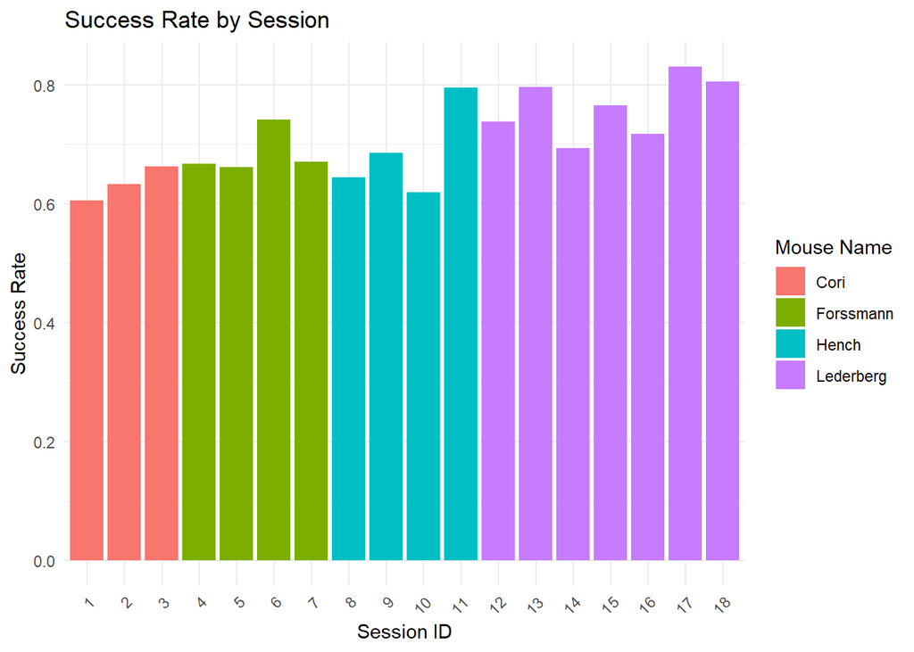

```r
ggplot(success_rates, aes(x=factor(session_id), y=success_rate, fill=mouse_name)) +
  geom_bar(stat="identity") +
  labs(title="Success Rate by Session",
       x="Session ID",
       y="Success Rate",
       fill="Mouse Name") +
  theme_minimal() +
  theme(axis.text.x = element_text(angle = 45, hjust = 1))
```

Finding - The overall high success rate indicates that the mice performed relatively consistently and stably. - The **Lederberg** mouse had the highest overall success rate while maintaining high stability, with no extreme data in success rates.

## 4.Data Integration

### 4.1 Neural Activity Normalization

```r
normalize_spks <- function(spks_matrix) {
  # Z-score normalization for each neuron
  spks_mean <- rowMeans(spks_matrix)
  spks_sd <- apply(spks_matrix, 1, sd)
  spks_sd[spks_sd == 0] <- 1  # Handle cases where standard deviation is 0
  normalized_spks <- sweep(sweep(spks_matrix, 1, spks_mean, "-"), 1, spks_sd, "/")
  return(normalized_spks)
}

# Example of normalization for Session 5
session_5_normalized <- list()
for(i in 1:length(session[[5]]$spks)) {
  session_5_normalized[[i]] <- normalize_spks(session[[5]]$spks[[i]])
}
original_stats <- c(
  mean = mean(session[[5]]$spks[[11]]),
  sd = sd(as.vector(session[[5]]$spks[[11]]))
)
normalized_stats <- c(
  mean = mean(session_5_normalized[[11]]),
  sd = sd(as.vector(session_5_normalized[[11]]))
)
print(original_stats)
```

```
##       mean         sd
## 0.02927112 0.17650535
```

```r
print("Normalized Data Statistics:")
```

```
## [1] "Normalized Data Statistics:"
```

```r
print(normalized_stats)
```

```
##          mean            sd
## -9.461048e-19  6.210182e-01
```

### 4.2 Brain Area Feature Extraction

```r
# Extract features for each brain area
extract_area_features <- function(spks_matrix, brain_areas) {
  unique_areas <- unique(brain_areas)
  area_features <- data.frame(
    brain_area = unique_areas,
    mean_rate = NA,
    peak_rate = NA,
    temporal_var = NA
  )

  for(area in unique_areas) {
    area_neurons <- which(brain_areas == area)
    area_spks <- spks_matrix[area_neurons,]

    area_features$mean_rate[area_features$brain_area == area] <- mean(area_spks)
    area_features$peak_rate[area_features$brain_area == area] <- max(colMeans(area_spks))
    area_features$temporal_var[area_features$brain_area == area] <- sd(colMeans(area_spks))
  }

  return(area_features)
}

session_5_features <- extract_area_features(session[[5]]$spks[[11]], session[[5]]$brain_area)

print(session_5_features)
```

```
##    brain_area   mean_rate  peak_rate temporal_var
## 1        VISa 0.015404040 0.07070707  0.016492898
## 2        root 0.045133588 0.08396947  0.014728902
## 3         CA1 0.007142857 0.03571429  0.014467705
## 4         SUB 0.023514851 0.06930693  0.014476522
## 5          DG 0.029687500 0.12500000  0.040000751
## 6         OLF 0.011464088 0.03867403  0.009641656
## 7         ORB 0.007031250 0.06250000  0.016577536
## 8         ACA 0.009433962 0.03773585  0.012818231
## 9          PL 0.007142857 0.07142857  0.021701558
## 10        MOs 0.013793103 0.06896552  0.021808811
```

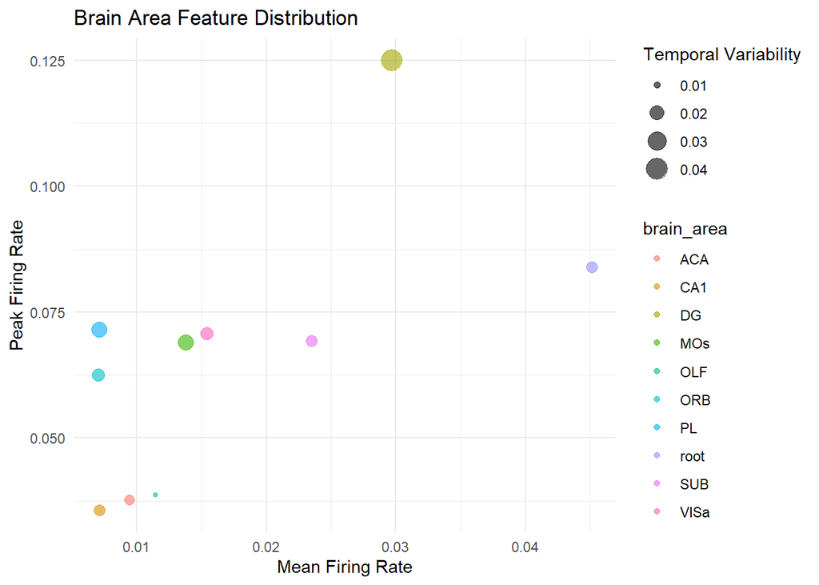

```r
# Visualize brain area features
ggplot(session_5_features, aes(x=mean_rate, y=peak_rate, size=temporal_var, color=brain_area)) +
  geom_point(alpha=0.6) +
  labs(title="Brain Area Feature Distribution",
       x="Mean Firing Rate",
       y="Peak Firing Rate",
       size="Temporal Variability") +
  theme_minimal()
```

### 4.3 Trial Condition Integration

```r
# Integrate trial conditions and results across all sessions
all_trials <- data.frame()
for(i in 1:18) {
  session_trials <- data.frame(
    session_id = i,
    mouse_name = session[[i]]$mouse_name,
    trial_id = 1:length(session[[i]]$feedback_type),
    contrast_left = session[[i]]$contrast_left,
    contrast_right = session[[i]]$contrast_right,
    feedback = session[[i]]$feedback_type
  )
  all_trials <- rbind(all_trials, session_trials)
}

# Analyze success rates under different stimulus conditions
contrast_success <- aggregate(feedback ~ contrast_left + contrast_right,
                            data = all_trials,
                            FUN = function(x) mean(x == 1))

print(contrast_success)
```

```
##    contrast_left contrast_right  feedback
## 1           0.00           0.00 0.6571845
## 2           0.25           0.00 0.6312849
## 3           0.50           0.00 0.8463476
## 4           1.00           0.00 0.8447489
## 5           0.00           0.25 0.7319588
## 6           0.25           0.25 0.4545455
## 7           0.50           0.25 0.6566265
## 8           1.00           0.25 0.7115839
## 9           0.00           0.50 0.8374233
## 10          0.25           0.50 0.6424581
## 11          0.50           0.50 0.4864865
## 12          1.00           0.50 0.6415094
## 13          0.00           1.00 0.7466960
## 14          0.25           1.00 0.7791798
## 15          0.50           1.00 0.6196319
## 16          1.00           1.00 0.5714286
```

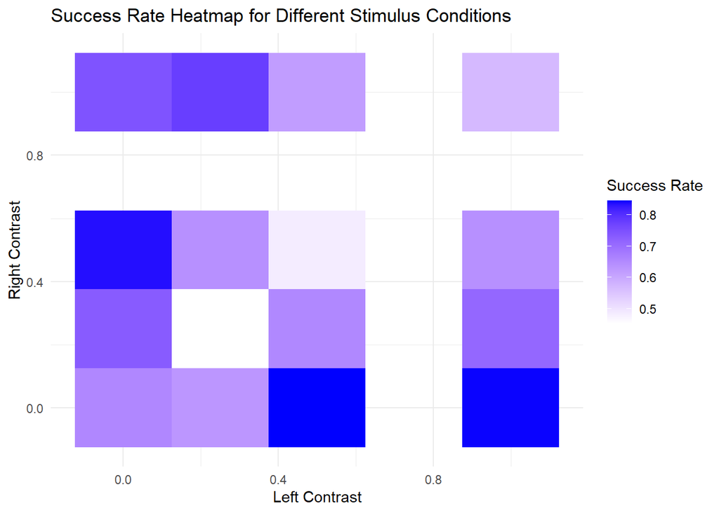

```r
# Visualize relationship between stimulus conditions and success rate
ggplot(contrast_success, aes(x=contrast_left, y=contrast_right, fill=feedback)) +
  geom_tile() +
  scale_fill_gradient(low="white", high="blue") +
  labs(title="Success Rate Heatmap for Different Stimulus Conditions",
       x="Left Contrast",
       y="Right Contrast",
       fill="Success Rate") +
  theme_minimal()
```

Finding - When **left contrast** is close to **0** and **right contrast** is around **0.4**, the success rate is relatively high. Conversely, the success rate is also high when the conditions are reversed. - The success rate is relatively lower when the contrast levels are similar. - There may be specific contrast combinations that make success more likely.

### 4.4 Session Similarity Analysis

```r
# Calculate similarity between sessions
calculate_session_similarity <- function(session1, session2) {
  # Use average success rate and stimulus condition distribution similarity
  success_diff <- abs(mean(session1$feedback_type == 1) - mean(session2$feedback_type == 1))

  # Calculate stimulus condition distribution similarity
  stim_dist1 <- table(paste(session1$contrast_left, session1$contrast_right))
  stim_dist2 <- table(paste(session2$contrast_left, session2$contrast_right))
  stim_similarity <- length(intersect(names(stim_dist1), names(stim_dist2))) /
                    length(union(names(stim_dist1), names(stim_dist2)))

  return(1 - (success_diff + (1 - stim_similarity))/2)
}

# Create session similarity matrix
n_sessions <- length(session)
similarity_matrix <- matrix(NA, n_sessions, n_sessions)
for(i in 1:n_sessions) {
  for(j in 1:n_sessions) {
    similarity_matrix[i,j] <- calculate_session_similarity(session[[i]], session[[j]])
  }
}

# Visualize session similarity
similarity_df <- reshape2::melt(similarity_matrix)
colnames(similarity_df) <- c("Session1", "Session2", "Similarity")

print(paste("Average similarity:", round(mean(similarity_matrix[upper.tri(similarity_matrix)]), 4)))
```

```
## [1] "Average similarity: 0.9595"
```

```r
print(paste("Maximum similarity:", round(max(similarity_matrix[upper.tri(similarity_matrix)]), 4)))
```

```
## [1] "Maximum similarity: 0.9996"
```

```r
print(paste("Minimum similarity:", round(min(similarity_matrix[upper.tri(similarity_matrix)]), 4)))
```

```
## [1] "Minimum similarity: 0.8875"
```

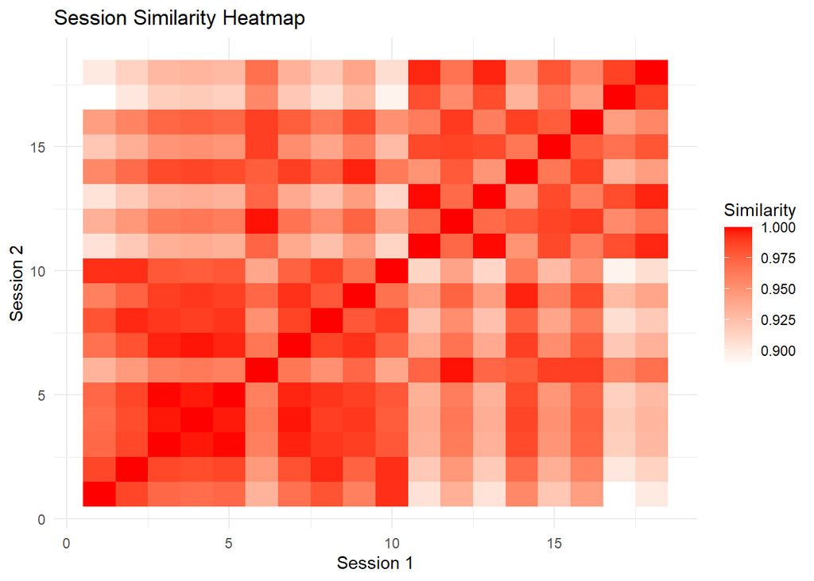

```r
ggplot(similarity_df, aes(x=Session1, y=Session2, fill=Similarity)) +
  geom_tile() +
  scale_fill_gradient(low="white", high="red") +
  labs(title="Session Similarity Heatmap",
       x="Session 1",
       y="Session 2") +
  theme_minimal()
```

## 5.Predictive Modeling

```r
all_brain_areas <- unique(unlist(lapply(session, function(x) unique(x$brain_area))))
print(all_brain_areas)
```

```
##  [1] "ACA"   "MOs"   "LS"    "root"  "VISp"  "CA3"   "SUB"   "DG"    "CA1"
## [10] "VISl"  "VISpm" "POST"  "VISam" "MG"    "SPF"   "LP"    "MRN"   "NB"
## [19] "LGd"   "TH"    "VPL"   "VISa"  "LSr"   "OLF"   "ORB"   "PL"    "AUD"
## [28] "SSp"   "LD"    "CP"    "EPd"   "PIR"   "ILA"   "TT"    "PO"    "ORBm"
## [37] "MB"    "SCm"   "SCsg"  "POL"   "GPe"   "VISrl" "MOp"   "LSc"   "PT"
## [46] "MD"    "LH"    "ZI"    "SCs"   "RN"    "MS"    "RSP"   "PAG"   "BLA"
## [55] "VPM"   "SSs"   "RT"    "MEA"   "ACB"   "OT"    "SI"    "SNr"
```

```r
extract_trial_features <- function(spks, brain_areas, all_areas) {
  # Initialize feature storage
  features <- list()

  # Calculate features for each brain area
  for(area in all_areas) {
    area_neurons <- which(brain_areas == area)
    if(length(area_neurons) > 0) {
      area_spks <- spks[area_neurons,]

      # Calculate basic statistics
      features[[paste0(area, "_mean_rate")]] <- mean(area_spks)
      features[[paste0(area, "_max_rate")]] <- max(colMeans(area_spks))
      features[[paste0(area, "_std_rate")]] <- sd(as.vector(area_spks))

      # Calculate time series features
      time_profile <- colMeans(area_spks)
      features[[paste0(area, "_peak_time")]] <- which.max(time_profile)
      features[[paste0(area, "_early_response")]] <- mean(time_profile[1:10])
      features[[paste0(area, "_late_response")]] <- mean(time_profile[31:40])
    } else {
      # Fill NA if brain area doesn't exist
      features[[paste0(area, "_mean_rate")]] <- 0
      features[[paste0(area, "_max_rate")]] <- 0
      features[[paste0(area, "_std_rate")]] <- 0
      features[[paste0(area, "_peak_time")]] <- 0
      features[[paste0(area, "_early_response")]] <- 0
      features[[paste0(area, "_late_response")]] <- 0
    }
  }

  # Calculate global features
  all_spks <- as.vector(spks)
  features$global_mean <- mean(all_spks)
  features$global_std <- sd(all_spks)
  features$global_max <- max(all_spks)

  # Calculate time window features
  time_bins <- seq(1, ncol(spks), by=10)
  for(i in 1:(length(time_bins)-1)) {
    bin_spks <- spks[, time_bins[i]:min(time_bins[i+1]-1, ncol(spks))]
    features[[paste0("time_bin_", i, "_mean")]] <- mean(bin_spks)
    features[[paste0("time_bin_", i, "_std")]] <- sd(as.vector(bin_spks))
  }

  return(unlist(features))
}

prepare_model_data <- function(session_id, session, all_areas) {
  n_trials <- length(session$feedback_type)

  features_list <- list()
  for(i in 1:n_trials) {
    features_list[[i]] <- extract_trial_features(session$spks[[i]],
                                               session$brain_area,
                                               all_areas)
  }

  X <- as.data.frame(do.call(rbind, features_list))

  X$contrast_left <- session$contrast_left
  X$contrast_right <- session$contrast_right
  X$contrast_diff <- abs(session$contrast_left - session$contrast_right)
  X$contrast_sum <- session$contrast_left + session$contrast_right
  X$contrast_product <- session$contrast_left * session$contrast_right

  return(list(X = X, y = session$feedback_type))
}

train_sessions <- 1:18
train_data <- list()
all_features <- NULL

for(i in train_sessions) {
  train_data[[i]] <- prepare_model_data(i, session[[i]], all_brain_areas)
  if(is.null(all_features)) {
    all_features <- colnames(train_data[[i]]$X)
  } else {
    all_features <- intersect(all_features, colnames(train_data[[i]]$X))
  }
  print(paste("Completed processing session", i))
}
```

```
## [1] "Completed processing session 1"
## [1] "Completed processing session 2"
## [1] "Completed processing session 3"
## [1] "Completed processing session 4"
## [1] "Completed processing session 5"
## [1] "Completed processing session 6"
## [1] "Completed processing session 7"
## [1] "Completed processing session 8"
## [1] "Completed processing session 9"
## [1] "Completed processing session 10"
## [1] "Completed processing session 11"
## [1] "Completed processing session 12"
## [1] "Completed processing session 13"
## [1] "Completed processing session 14"
## [1] "Completed processing session 15"
## [1] "Completed processing session 16"
## [1] "Completed processing session 17"
## [1] "Completed processing session 18"
```

```r
X_list <- list()
y_list <- list()
for(i in seq_along(train_data)) {
  X_list[[i]] <- train_data[[i]]$X[, all_features]
  y_list[[i]] <- train_data[[i]]$y
}

X_train <- do.call(rbind, X_list)
y_train <- unlist(y_list)

nzv <- nearZeroVar(X_train, saveMetrics = TRUE)
X_train <- X_train[, !nzv$nzv]

# Standardization
preprocess_params <- preProcess(X_train, method = c("center", "scale"))
X_train_processed <- predict(preprocess_params, X_train)

# Convert labels to factors
y_train_factor <- factor(ifelse(y_train == 1, "success", "failure"))

ctrl <- trainControl(
  method = "cv",
  number = 5,
  classProbs = TRUE,
  summaryFunction = twoClassSummary,
  savePredictions = TRUE
)

# Use grid search to optimize hyperparameters
rf_grid <- expand.grid(
  mtry = c(floor(sqrt(ncol(X_train_processed))),
           floor(ncol(X_train_processed)/3),
           floor(ncol(X_train_processed)/2))
)

print("Random Forest model training")
```

```
## [1] "Random Forest model training"
```

```r
rf_model <- train(
  x = X_train_processed,
  y = y_train_factor,
  method = "rf",
  metric = "ROC",
  trControl = ctrl,
  tuneGrid = rf_grid,
  ntree = 500
)


test_session_1 <- readRDS("C:/Users/hong7/Desktop/test/test1.rds")
test_session_2 <- readRDS("C:/Users/hong7/Desktop/test/test2.rds")
test_data_1 <- prepare_model_data(19, test_session_1, all_brain_areas)
test_data_2 <- prepare_model_data(20, test_session_2, all_brain_areas)

X_test_1 <- test_data_1$X[, all_features]
X_test_1 <- X_test_1[, !nzv$nzv]
X_test_2 <- test_data_2$X[, all_features]
X_test_2 <- X_test_2[, !nzv$nzv]

# Preprocess test data
X_test_processed_1 <- predict(preprocess_params, X_test_1)
X_test_processed_2 <- predict(preprocess_params, X_test_2)

X_test_processed_1 <- na.omit(X_test_processed_1)
X_test_processed_2 <- na.omit(X_test_processed_2)


# Make predictions
predictions_1 <- predict(rf_model, X_test_processed_1)
probabilities_1 <- predict(rf_model, X_test_processed_1, type = "prob")
predictions_2 <- predict(rf_model, X_test_processed_2)
probabilities_2 <- predict(rf_model, X_test_processed_2, type = "prob")

# Evaluate model
conf_matrix_1 <- confusionMatrix(predictions_1, factor(ifelse(test_data_1$y == 1, "success", "failure")))
conf_matrix_2 <- confusionMatrix(predictions_2, factor(ifelse(test_data_1$y == 1, "success", "failure")))
print("Confusion Matrix:")
```

```
## [1] "Confusion Matrix:"
```

```r
print(conf_matrix_1)
```

```
## Confusion Matrix and Statistics
##
##           Reference
## Prediction failure success
##    failure      14      11
##    success      14      61
##
##                Accuracy : 0.75
##                  95% CI : (0.6534, 0.8312)
##     No Information Rate : 0.72
##     P-Value [Acc > NIR] : 0.2929
##
##                   Kappa : 0.359
##
##  Mcnemar's Test P-Value : 0.6892
##
##             Sensitivity : 0.5000
##             Specificity : 0.8472
##          Pos Pred Value : 0.5600
##          Neg Pred Value : 0.8133
##              Prevalence : 0.2800
##          Detection Rate : 0.1400
##    Detection Prevalence : 0.2500
##       Balanced Accuracy : 0.6736
##
##        'Positive' Class : failure
##
```

```r
print(conf_matrix_2)
```

```
## Confusion Matrix and Statistics
##
##           Reference
## Prediction failure success
##    failure       2       4
##    success      26      68
##
##                Accuracy : 0.7
##                  95% CI : (0.6002, 0.7876)
##     No Information Rate : 0.72
##     P-Value [Acc > NIR] : 0.714912
##
##                   Kappa : 0.0209
##
##  Mcnemar's Test P-Value : 0.000126
##
##             Sensitivity : 0.07143
##             Specificity : 0.94444
##          Pos Pred Value : 0.33333
##          Neg Pred Value : 0.72340
##              Prevalence : 0.28000
##          Detection Rate : 0.02000
##    Detection Prevalence : 0.06000
##       Balanced Accuracy : 0.50794
##
##        'Positive' Class : failure
##
```

```r
# ROC curve
roc_obj_1 <- roc(factor(ifelse(test_data_1$y == 1, "success", "failure")), probabilities_1[,"success"])
roc_obj_2 <- roc(factor(ifelse(test_data_2$y == 1, "success", "failure")), probabilities_2[,"success"])
print(auc(roc_obj_1))
```

```
## Area under the curve: 0.7748
```

```r
print(auc(roc_obj_2))
```

```
## Area under the curve: 0.8133
```

# Plot ROC curve

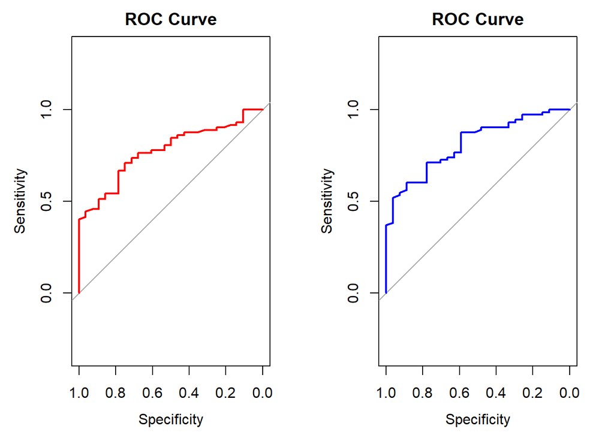

```r
par(mfrow = c(1,2))
plot(roc_obj_1, col = "red" ,main="ROC Curve")
plot(roc_obj_2, col = "blue" , main="ROC Curve")
```

## 8.Acknowledge

1. Chen, Shizhe, Courses, Notes, Codes, and all work you offer us in STA141A
2. Chen, Shizhe, Courses, Discussion:Project Demo in STA141A
3. Some of the correct formatting and error corrections in the code were inspired by ChatGPT.

## 9.Reference

Steinmetz, N.A., Zatka-Haas, P., Carandini, M. et al. Distributed coding of choice, action and engagement across the mouse brain. Nature 576, 266–273 (2019). https://doi.org/10.1038/s41586-019-1787-x